# NonLinear Relationships

Stephen Locke

2023-11-02

```r
# setting the directory
setwd('/Users/stp48131/Library/CloudStorage/Dropbox/WKU/Teaching/ECON_307/Class_Materials/Honors/Non-Linear')

# loading the tidyverse library
# if you have not installed this enter install.packages('tidyverse) in the console
library(readxl)
library(ggplot2) # for graphics

# loading the excel file that contains the data
# Electricity is kWh, not dollars.
data <- read_excel('NonLinear_R.xlsx',
                   .name_repair = 'universal' # cleans variable names
                   )


# attaching the data frame. doing this allows us to reference
# variables without specifying the data dataframe each time
attach(data)
```

Notice the obvious non-linear relationship.

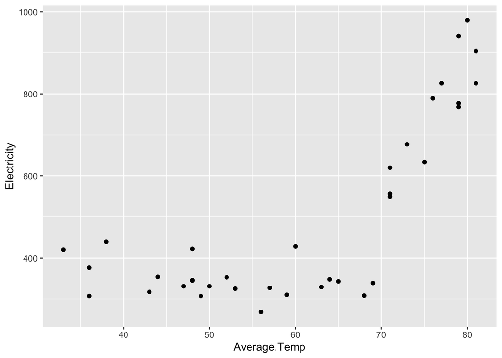

```r
## scatter plot
ggplot(data, aes(x=Average.Temp, y=Electricity)) +
  geom_point()
```

I am estimating all of the models even though they may not be ideal for this data.

```r
## linear model
linear<-lm(Electricity~Average.Temp, data=data)
summary(linear)
```

```
##
## Call:
## lm(formula = Electricity ~ Average.Temp, data = data)
##
## Residuals:
##      Min       1Q   Median       3Q      Max
## -271.242  -69.331   -8.261   91.444  265.470
##
## Coefficients:
##              Estimate Std. Error t value Pr(>|t|)
## (Intercept)  -187.392    101.840  -1.840   0.0745 .
## Average.Temp   11.274      1.635   6.894 6.09e-08 ***
## ---
## Signif. codes:  0 '***' 0.001 '**' 0.01 '*' 0.05 '.' 0.1 ' ' 1
##
## Residual standard error: 143.7 on 34 degrees of freedom
## Multiple R-squared:  0.583,  Adjusted R-squared:  0.5707
## F-statistic: 47.53 on 1 and 34 DF,  p-value: 6.094e-08
```

On average, electricity usage increases by 11.27 kWh for each one degree increase in average temperature.

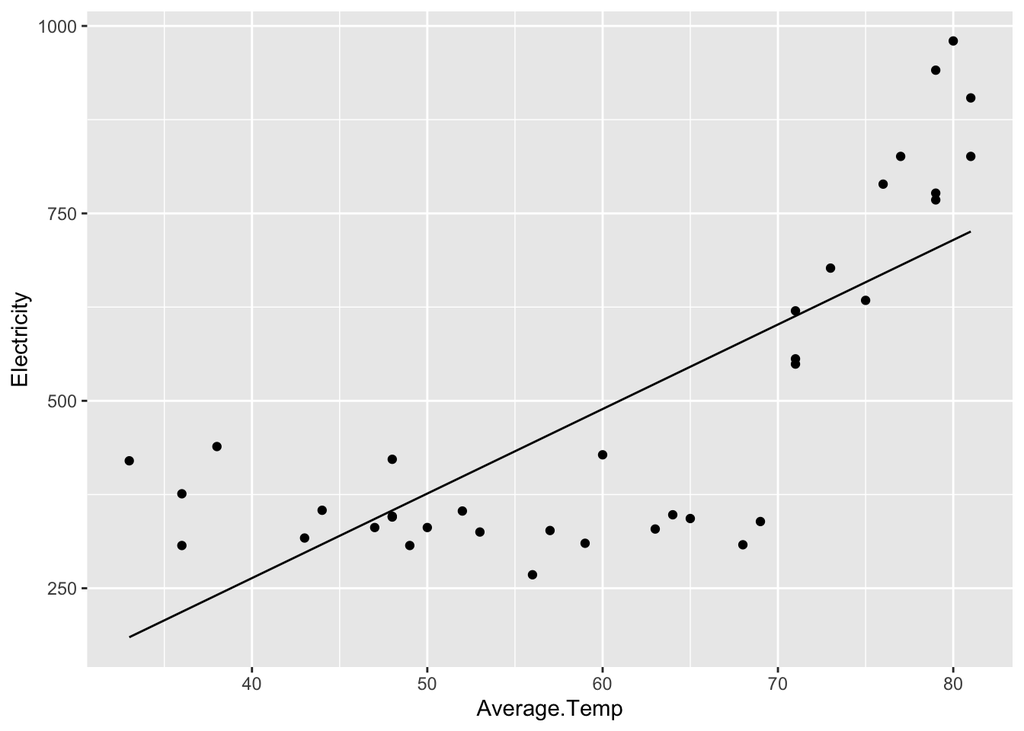

```r
# adding the linear regression to the plot
ggplot(data, aes(x=Average.Temp, y=Electricity)) +
  geom_point() +
  geom_line(aes(y=linear$fitted.values))
```

```r
## quadratic
# generating average temp squared
data$temp_sq=Average.Temp^2

quad<-lm(Electricity~Average.Temp+temp_sq, data=data)
summary(quad)
```

```
##
## Call:
## lm(formula = Electricity ~ Average.Temp + temp_sq, data = data)
##
## Residuals:
##      Min       1Q   Median       3Q      Max
## -184.216  -48.695    8.296   53.785  128.399
##
## Coefficients:
##                Estimate Std. Error t value Pr(>|t|)
## (Intercept)  1895.14143  236.40201   8.017 3.00e-09 ***
## Average.Temp  -63.92740    8.34679  -7.659 8.11e-09 ***
## temp_sq         0.63671    0.07027   9.061 1.80e-10 ***
## ---
## Signif. codes:  0 '***' 0.001 '**' 0.01 '*' 0.05 '.' 0.1 ' ' 1
##
## Residual standard error: 78.11 on 33 degrees of freedom
## Multiple R-squared:  0.8804, Adjusted R-squared:  0.8732
## F-statistic: 121.5 on 2 and 33 DF,  p-value: 6.03e-16
```

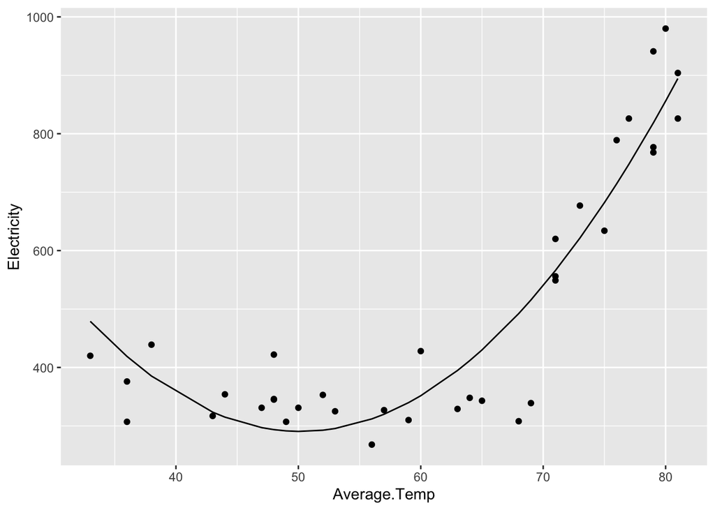

```r
# adding the quadratic regression to the plot
ggplot(data, aes(x=Average.Temp, y=Electricity)) +
  geom_point() +
  geom_line(aes(y=quad$fitted.values))
```

```r
## log dependent
## log() gives the natural log by default so you do not need to use ln()
## you do not have to generate a new variable for this
lny<-lm(log(Electricity)~Average.Temp, data=data)
summary(lny)
```

```
##
## Call:
## lm(formula = log(Electricity) ~ Average.Temp, data = data)
##
## Residuals:
##      Min       1Q   Median       3Q      Max
## -0.54261 -0.16358 -0.00796  0.17887  0.48318
##
## Coefficients:
##              Estimate Std. Error t value Pr(>|t|)
## (Intercept)  4.882341   0.191913  25.440  < 2e-16 ***
## Average.Temp 0.020447   0.003082   6.635 1.31e-07 ***
## ---
## Signif. codes:  0 '***' 0.001 '**' 0.01 '*' 0.05 '.' 0.1 ' ' 1
##
## Residual standard error: 0.2708 on 34 degrees of freedom
## Multiple R-squared:  0.5642, Adjusted R-squared:  0.5514
## F-statistic: 44.02 on 1 and 34 DF,  p-value: 1.306e-07
```

On average, each one degree increase in average temperature increases electricity usage by 2%.

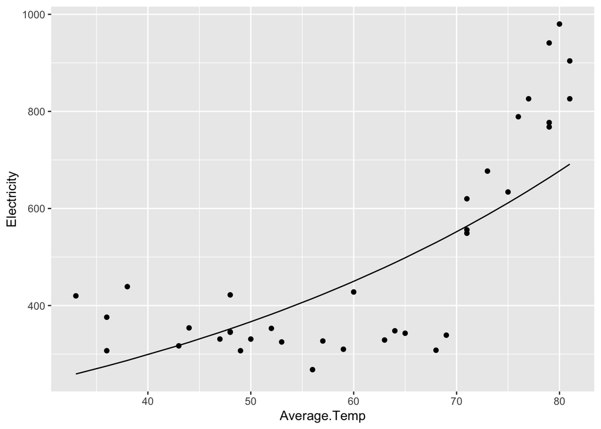

```r
# adding the fitted regression to the plot
ggplot(data, aes(x=Average.Temp, y=Electricity)) +
  geom_point() +
  geom_line(aes(y=exp(lny$fitted.values)))
```

```r
## log independent
## you do not have to generate a new variable for this
lnx<-lm(Electricity~log(Average.Temp), data=data)
summary(lnx)
```

```
##
## Call:
## lm(formula = Electricity ~ log(Average.Temp), data = data)
##
## Residuals:
##     Min      1Q  Median      3Q     Max
## -273.19  -90.90  -18.55  117.40  304.49
##
## Coefficients:
##                   Estimate Std. Error t value Pr(>|t|)
## (Intercept)        -1867.7      417.2  -4.477 8.10e-05 ***
## log(Average.Temp)    580.4      102.3   5.675 2.28e-06 ***
## ---
## Signif. codes:  0 '***' 0.001 '**' 0.01 '*' 0.05 '.' 0.1 ' ' 1
##
## Residual standard error: 159.5 on 34 degrees of freedom
## Multiple R-squared:  0.4864, Adjusted R-squared:  0.4713
## F-statistic:  32.2 on 1 and 34 DF,  p-value: 2.279e-06
```

On average, a 1% increase in average temperature increases electricity usage by 5.8 kWh. The plot below confirms that this regression equation is not appropriate for this data.

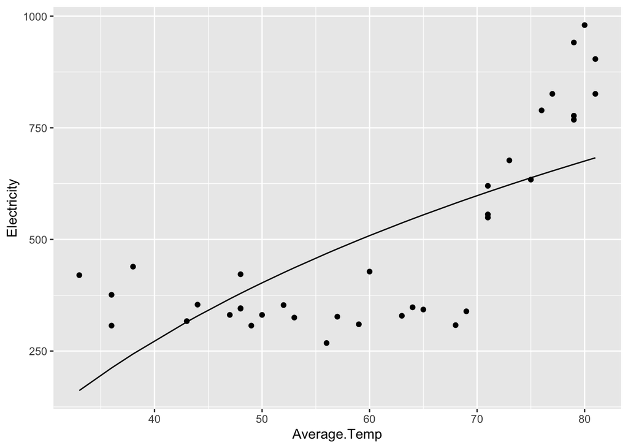

```r
# adding the fitted regression to the plot
ggplot(data, aes(x=Average.Temp, y=Electricity)) +
  geom_point() +
  geom_line(aes(y=lnx$fitted.values))
```